# R Notebook

### 24.2.1 Price and carat

It looks like lower quality diamonds have higher prices because there is an important confounding variable: the weight (`carat`) of the diamond. The weight of the diamond is the single most important factor for determining the price of the diamond, and lower quality diamonds tend to be larger.

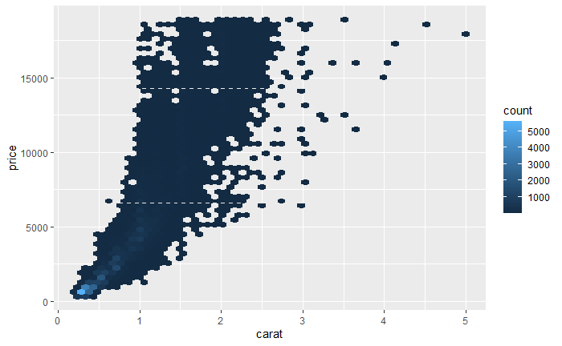

```r
ggplot(diamonds, aes(carat, price)) + geom_hex(bins=50)
```

We can make it easier to see how the other attributes of a diamond affect its relative `price` by fitting a model to separate out the effect of `carat`. But first, lets make a couple of tweaks to the diamonds dataset to make it easier to work with:

1. Focus on diamonds smaller than 2.5 carats (99.7% of the data)
2. Log-transform the carat and price variables.

```r
diamonds2 <- diamonds %>%
    filter(carat <= 2.5) %>%
    mutate(lprice=log2(price), lcarat=log2(carat))
```

[figure not shown]

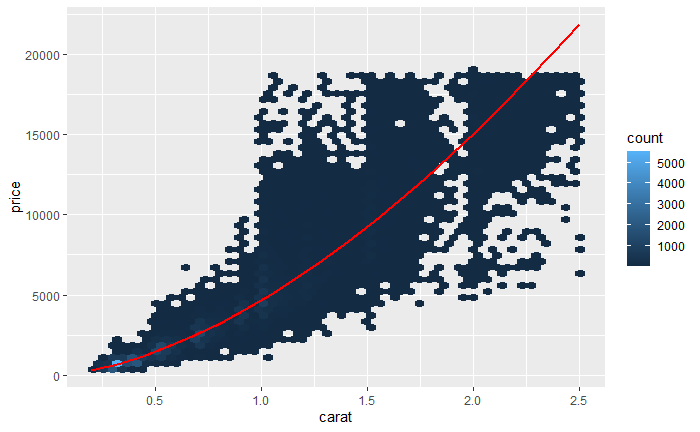

```r
grid <- diamonds2 %>%
  data_grid(carat = seq_range(carat, 20)) %>%
  mutate(lcarat = log2(carat)) %>%
  add_predictions(mod_diamond, "lprice") %>%
  mutate(price = 2 ^ lprice)

ggplot(diamonds2, aes(carat, price)) + geom_hex(bins=50) + geom_line(data = grid, colour="red", size = 1)
```

Now we can look at the residuals, which verifies that we’ve successfully removed the strong linear pattern:

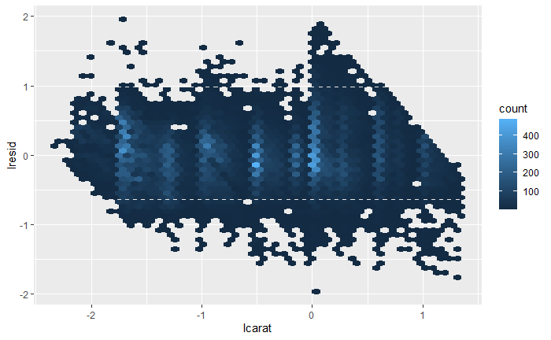

```r
diamonds2 <- diamonds2 %>%
  add_residuals(mod_diamond, "lresid")

ggplot(diamonds2, aes(lcarat, lresid)) + geom_hex(bins=50)
```

Importantly, we can now re-do our motivating plots using those residuals instead of price.

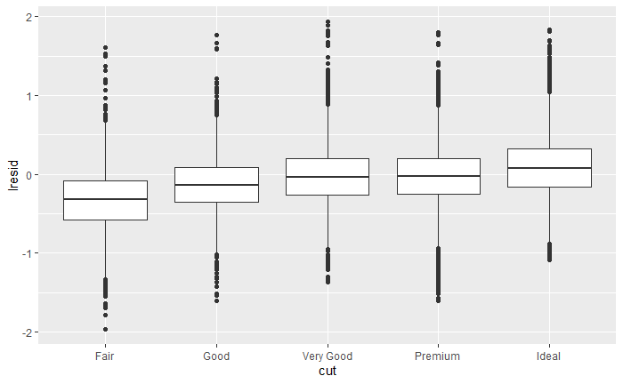

```r
ggplot(diamonds2, aes(cut, lresid)) + geom_boxplot()
```

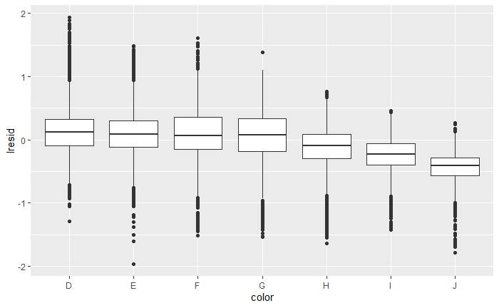

```r
ggplot(diamonds2, aes(color, lresid)) + geom_boxplot()
```

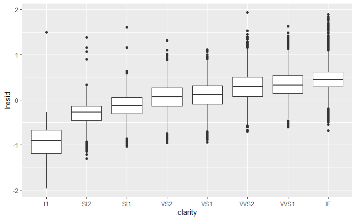

```r
ggplot(diamonds2, aes(clarity, lresid)) + geom_boxplot()
```

### 24.2.2 A more complicated model

If we wanted to, we could continue to build up our model, moving the effects we’ve observed into the model to make them explicit. For example, we could include `color`, `cut`, and `clarity` into the model so that we also make explicit the effect of these three categorical variables:

```r
mod_diamond2 <- lm(lprice ~ lcarat + color + cut + clarity, data=diamonds2)
```

This model now includes four predictors, so it’s getting harder to visualise. Fortunately, they’re currently all independent which means that we can plot them individually in four plots. To make the process a little easier, we’re going to use the `.model` argument to `data_grid`:

```r
grid <- diamonds2 %>%
  data_grid(cut, .model = mod_diamond2) %>%
  add_predictions(mod_diamond2)
```